# Variable Suppression and Recoding: SDSS 2022 Short Course

Joshua Snoke

2022-06-07

## Simulated Data Example

Start by loading in a simulated data set of a teacher survey. The file contains individual and school characteristics. Print out the first 25 rows to get an idea of the variables.

```r
simulated_survey_data = read_csv('simulated_suppression_data.csv',
                                 show_col_types = FALSE) %>%
  mutate_all(as.factor)
print(simulated_survey_data,
      n = 25)
```

```
## # A tibble: 10,000 × 8
##    State School_Level School_Locality School_Size Subject Race     Gender
##    <fct> <fct>        <fct>           <fct>       <fct>   <fct>    <fct>
##  1 RI    Middle       Urban           250to499    ELA     White    Female
##  2 RI    Middle       Suburban        500to999    NatSci  White    Female
##  3 PA    Elementary   Urban           1000Plus    NatSci  White    Female
##  4 OH    High         Urban           250to499    ELA     White    Female
##  5 MS    Middle       Suburban        250to499    ELA     White    Female
##  6 RI    High         Rural           250to499    ELA     White    Female
##  7 KY    Elementary   Urban           500to999    NatSci  White    Female
##  8 NE    High         Rural           1000Plus    Math    White    Female
##  9 GA    Elementary   Rural           500to999    ELA     White    Female
## 10 AR    Elementary   Rural           500to999    ELA     White    Female
## 11 TX    Elementary   Urban           500to999    ELA     White    Female
## 12 GA    High         Suburban        500to999    ELA     Other    Female
## 13 NE    High         Suburban        500to999    ELA     Other    Male
## 14 GA    Elementary   Town            1000Plus    ELA     White    Female
## 15 NC    Elementary   Town            500to999    NatSci  White    Female
## 16 SC    Middle       Urban           Lessthan250 NatSci  White    Female
## 17 NM    High         Town            1000Plus    NatSci  White    Female
## 18 NM    Elementary   Urban           250to499    ELA     White    Male
## 19 KY    Elementary   Suburban        250to499    NatSci  White    Female
## 20 NY    High         Urban           500to999    ELA     White    Female
## 21 MA    Elementary   Suburban        500to999    ELA     Hispanic Female
## 22 DE    Elementary   Suburban        500to999    NatSci  White    Female
## 23 WV    Elementary   Urban           250to499    ELA     White    Female
## 24 FL    Elementary   Suburban        250to499    ELA     White    Male
## 25 CA    Elementary   Suburban        500to999    ELA     White    Female
## # … with 9,975 more rows, and 1 more variable: Experience <fct>
```

We can also tabulate the variables to get an idea of the distributions.

```r
summary(simulated_survey_data,
        maxsum = 8)
```

```
##      State          School_Level  School_Locality      School_Size
##  FL     : 629   Elementary:5158   Rural   :2292   1000Plus   :2205
##  OH     : 616   High      :2993   Suburban:3611   250to499   :3223
##  CA     : 579   Middle    :1849   Town    :1472   500to999   :3850
##  NY     : 577                     Urban   :2625   Lessthan250: 722
##  KY     : 546
##  TN     : 534
##  TX     : 521
##  (Other):5998
##    Subject            Race         Gender         Experience
##  ELA   :4191   AIAN     :  34   Female:8288   10to15   :2537
##  Math  :3228   Asian    : 130   Male  :1712   16Plus   :4645
##  NatSci:2581   Black    : 591                 3to9     :2700
##                Hispanic : 786                 Lessthan3: 118
##                Multirace: 209
##                NHPI     :  23
##                Other    :  50
##                White    :8177
```

## Identification Risk Among the Sample

First, let’s look just at frequencies of characteristics among those in the survey. We have a lot of characteristics, so the majority of teachers are unique if we used every variable and level as provided.

```r
trivial_freq = simulated_survey_data %>%
  ## here we are computing all combinations of the characteristics
  group_by_all() %>%
  summarize(freq = n())

table(trivial_freq$freq)
```

```
##
##    1    2    3    4    5    6    7    8
## 5697 1035  393  128   57   23    9    7
```

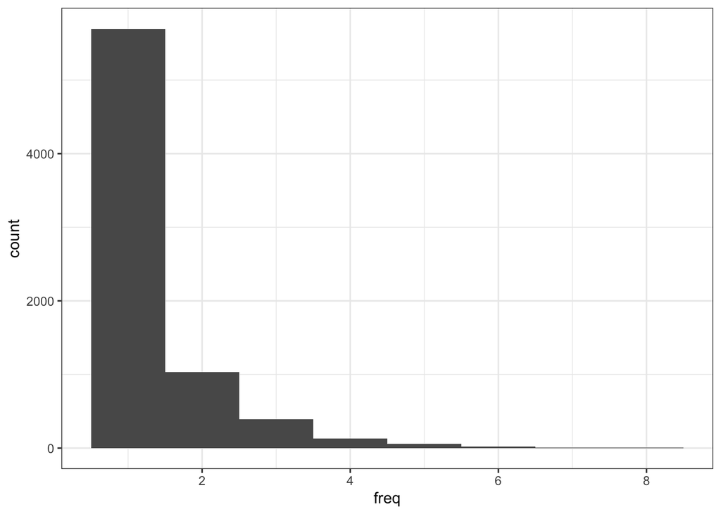

```r
## We can also plot the frequencies
ggplot(trivial_freq, aes(x = freq)) +
  geom_histogram(binwidth = 1) +
  theme_bw()
```

```r
## We can calculate risk based on 1 / Freq
summary(1 / trivial_freq$freq)
```

```
##    Min. 1st Qu.  Median    Mean 3rd Qu.    Max.
##  0.1250  1.0000  1.0000  0.8702  1.0000  1.0000
```

State is a pretty identifying characteristic, so let’s see what happens when we suppress the state variable.

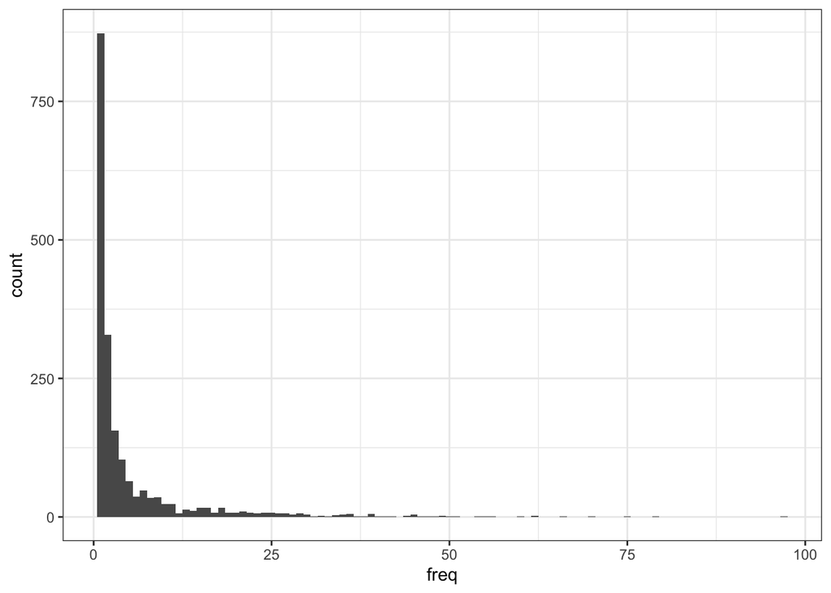

```r
no_state_freq = simulated_survey_data %>%
  ## here we are dropping state from our calculations (i.e., suppressing it)
  group_by_at(vars(-State)) %>%
  summarize(freq = n())

ggplot(no_state_freq, aes(x = freq)) +
  geom_histogram(binwidth = 1) +
  theme_bw()
```

```r
## how many teachers are still unique?
sum(no_state_freq$freq == 1)
```

```
## [1] 873
```

```r
## Risk has dropped but is still high
summary(1 / no_state_freq$freq)
```

```
##    Min. 1st Qu.  Median    Mean 3rd Qu.    Max.
## 0.01031 0.23750 0.50000 0.59769 1.00000 1.00000
```

We want to do more, so let’s collapse some of the small levels for Race, Experience, and School Size

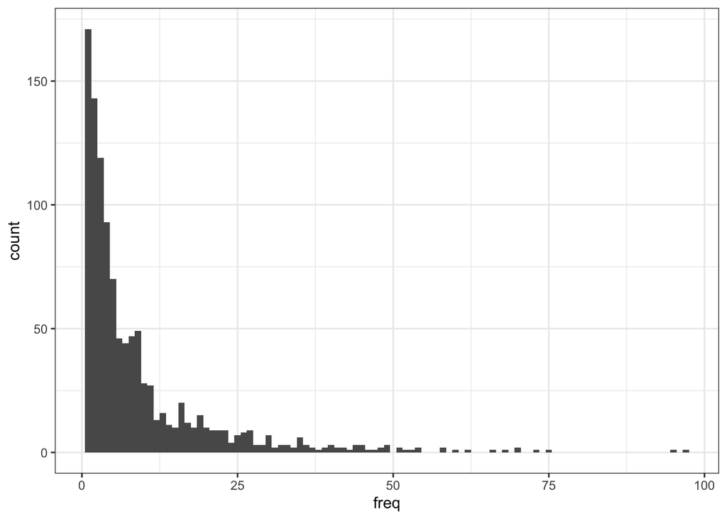

```r
no_state_collapsed_freq = simulated_survey_data %>%
  ## here we collapse levels for Race and Experience
  mutate(Race = recode(Race,
                       `AIAN` = 'Other',
                       `NHPI` = 'Other',
                       `Asian` = 'Other',
                       `Multirace` = 'Other',
                       `Black` = 'Other',
                       `Hispanic` = 'Other'),
         Experience = recode(Experience,
                             `Lessthan3` = 'Lessthan10',
                             `3to9` = 'Lessthan10'),
         School_Size = recode(School_Size,
                              `Lessthan250` = 'Lessthan500',
                              `250to499` = 'Lessthan500')) %>%
  ## here we still drop state from our calculations (i.e., suppressing it)
  group_by_at(vars(-State)) %>%
  summarize(freq = n())

ggplot(no_state_collapsed_freq, aes(x = freq)) +
  geom_histogram(binwidth = 1) +
  theme_bw()
```

```r
## how many teachers are still unique?
sum(no_state_collapsed_freq$freq == 1)
```

```
## [1] 171
```

```r
## Risk has dropped again but is still high
summary(1 / no_state_collapsed_freq$freq)
```

```
##    Min. 1st Qu.  Median    Mean 3rd Qu.    Max.
## 0.01031 0.09091 0.20000 0.33339 0.50000 1.00000
```

## Identification Risk with Population Frequencies

Now, let’s assume that participation in the survey is not known. In this case, we need to factor in the likelihood that an individual was sampled into the survey. We do this using population frequencies.

```r
simulated_population = read_csv('simulated_suppression_population.csv',
                                show_col_types = FALSE) %>%
  mutate_at(vars(-pop_total), as.factor)
```

We calculate risk using both the survey frequencies and the population frequencies.

```r
## survey freq are the same as before
trivial_pop_freq = simulated_survey_data %>%
  ## here we are computing all combinations of the characteristics
  group_by_all() %>%
  summarize(freq = n()) %>%
  ## merge with population freq
  left_join(simulated_population) %>%
  ## Risk is now based on the population frequencies
  mutate(risk = 1 / pop_total,
         sample_unique = freq == 1)
```

[output not shown]

```r
## Risk is now the multiplication of the two
summary(trivial_pop_freq$risk)
```

```
##    Min. 1st Qu.  Median    Mean 3rd Qu.    Max.
## 0.01724 0.05882 0.07692 0.10105 0.11111 1.00000
```

```r
## Much lower than before, but still some population uniques
sum(trivial_pop_freq$pop_total == 1)
```

```
## [1] 22
```

If we drop state and Race in this case, our risk is substantially lower.

```r
## survey freq are the same as before
no_state_pop_freq = simulated_survey_data %>%
  ## here we are computing all combinations of the characteristics
  group_by_at(vars(-State,
                   -Race)) %>%
  summarize(freq = n()) %>%
  ## merge with population freq that are calculated based on dropped variables
  left_join(simulated_population %>%
              group_by_at(vars(-State,
                               -Race,
                               -pop_total)) %>%
              summarize(pop_total = sum(pop_total))) %>%
  ## Risk is now based on the population frequencies
  mutate(risk = 1 / pop_total,
         sample_unique = freq == 1)
```

[output not shown]

```r
summary(no_state_pop_freq$risk)
```

```
##     Min.  1st Qu.   Median     Mean  3rd Qu.     Max.
## 0.001093 0.006250 0.015038 0.031863 0.038462 0.333333
```

```r
## No longer any population uniques
sum(no_state_pop_freq$pop_total == 1)
```

```
## [1] 0
```

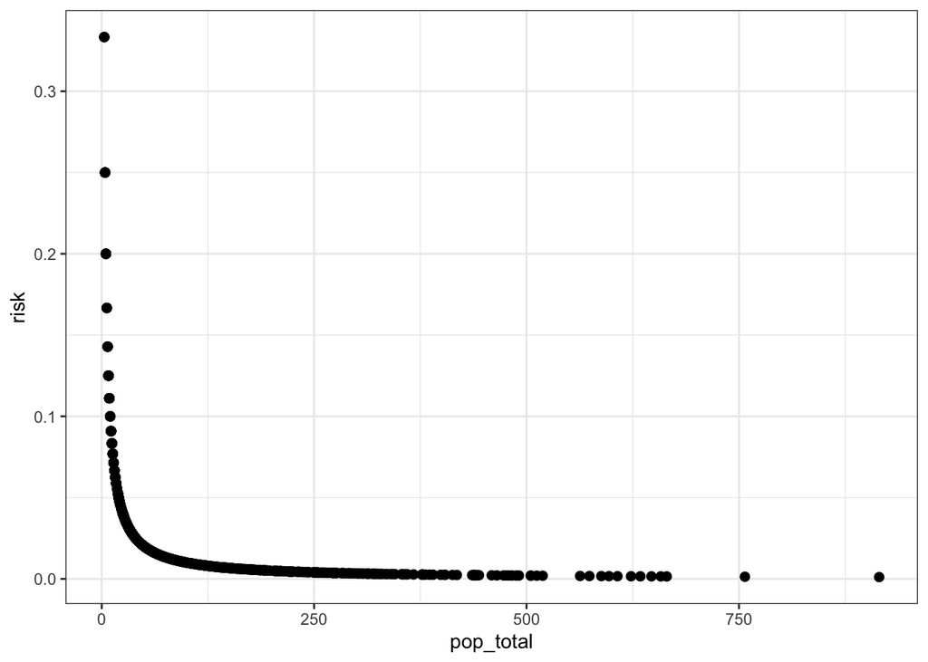

```r
## we can visual risk values against the population totals
ggplot(no_state_pop_freq, aes(y = risk, x = pop_total)) +
  geom_point(size = 2) +
  theme_bw()
```

## Try One or More of the Following Yourself

1. Produce a combination of variables/levels with max risk less than 0.1.
2. Produce a combination of variables/levels with mean risk less than 0.01
3. Produce a combination of variables/levels with total risk less than 1.
4. Or use your own data!